# COMP280 Week 11: Workshop

Alcwyn Parker

06 December, 2019

## Register Attendance

[figure not shown]

Attendance monitoring is in place. It is your responsability to ensure that you have signed yourself in.

## Learning Outcomes

After completing this worksheet you will be able to:

- **Create** new scripts
- **Design** UI in Unity
- **Connect** a progress bar widget to a c# variable

*Using Unity 2018.4.3f1

# PART 1 - SETUP

## 1. Create Project

- Launch Unity
- Create a new 3D project

[figure not shown]

## 2. Asset Pack

- Go to the asset store
- Search for the ‘Standard Assets’
- Download and Import

[figure not shown]

## FirstPerson

- Open the FPS Scene insde the imported assets.

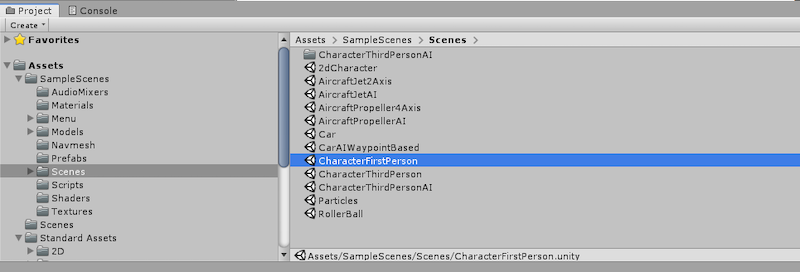

## Canvas

- Add a canvas to the scene and rename it ‘HUD’

[figure not shown]

## Slider

Now add a Slide Bar UI component and rename it ‘HealthBar’

[figure not shown]

## Delete

- Delete the ‘Handle Slide Area’ from insider the Slide Bar. We don’t need this for health.

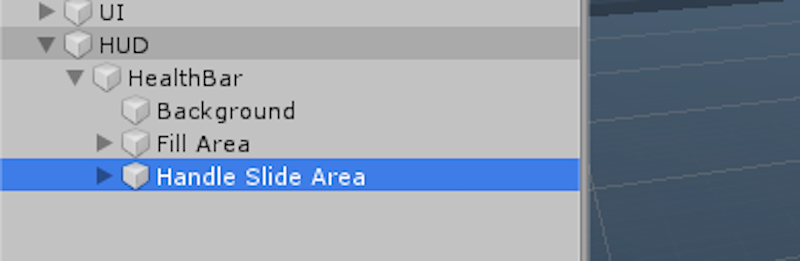

## Slider Target Graphic

- Now grab the fill from inside the ‘Fill Area’ and Drag it on to the ‘Target Graphic’ property of the main HealthBar component.

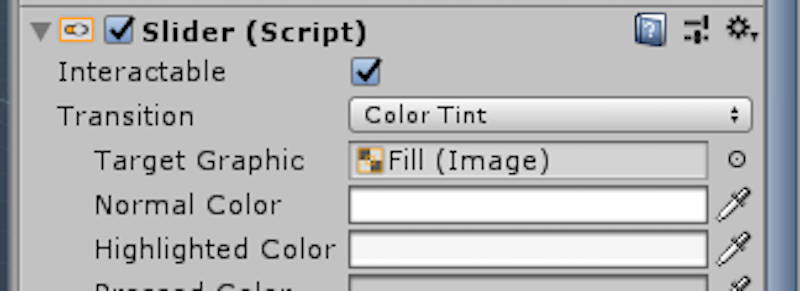

## Set Fill Width

- Now click the ‘Fill’ object inside of ‘Fill Area’ and set the width to 0 in the inspector.

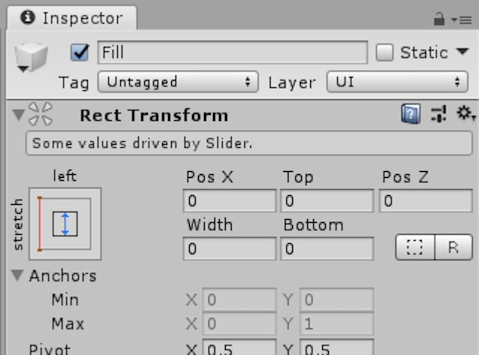

## Adjust the Fill Dimensions

- Using the Rect tool in the editor, adjust the ‘Fill Area’ dimensions to fit the ‘Background’ better.

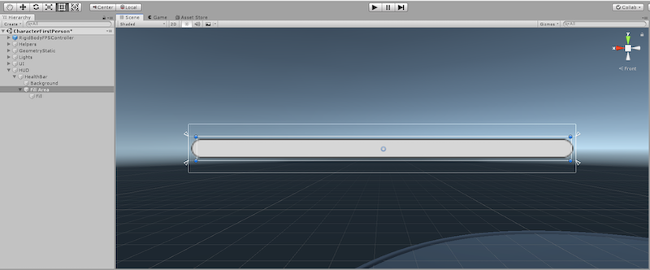

## Final HealthBar Inspector Settings

- Now make sure the the hierarchy and HealthBar inspector settings match what can be seen below.

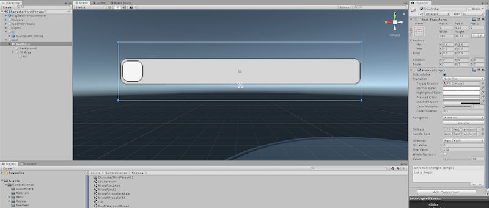

## Test with a Script

Now, Import the UI resources at the top of the file: `using UnityEngine.UI;`

Add the variables above ‘void Start()’:

```
Slider sliderComponent;
float healthValue = 100f;
```

Inside ‘void Start()’ add:

```
sliderComponent = GetComponent<Slider>();
InvokeRepeating("UpdateLoop", 2.0f, 0.3f);
```

Add a timer function at the bottom of the class:

```
void UpdateLoop()
{
     healthValue += 10;
     if (healthValue > 100) healthValue = 0;
    sliderComponent.value = healthValue;
}
```

## The Final File

```
using System.Collections;
using System.Collections.Generic;
using UnityEngine;
using UnityEngine.UI;
public class HealthIncrement : MonoBehaviour
{
    Slider sliderComponent;
    float healthValue = 100f;
    // Start is called before the first frame update
    void Start()
    {
        sliderComponent = GetComponent<Slider>();
        InvokeRepeating("UpdateLoop", 2.0f, 0.3f);
    }
    // Update is called once per frame
    void Update()
    {
    }
    void UpdateLoop()
    {
         healthValue += 10;
         if (healthValue > 100) healthValue = 0;
        sliderComponent.value = healthValue;
    }
}
```

## Add Script to Scene

Go back to Unity and drag the new script from the project explorer onto the HealthBar object in the scene.

Press Play to test